# Understanding Deleterious Effects of Storms using the NOAA Storm Data

Submitted for Coursera **Reproducable Research Peer Assessment 2

2015 NOV 22

## Data Processing

*NOTE: This section is full of arcane technical minutiae that will bore you if all you want is the answer; that can be found in the Results section.*

In this section we will perform all the analysis in a way that you can reproduce the results. Note that due to the way this analysis starts with the current NOAA database, your results may vary.

### Load data for analysis

1. Load necessary library for analysis
2. Get the data from it’s source
3. Load the data into the tools to do the analysis
4. Tidy up the data to get it more amenable to work with

#### Load libraries

It’s simpler to load all the libraries at the beginning, so we’ll do that here. That way, any noise generated by loading the libraries are nicely contained in this section.

```r
library(downloader)
library(data.table)
library(ggplot2)
library(scales)
library(R.utils)
library(dplyr)
```

#### Get the data from the source.

Now that the libraries are loaded and the tool is ready to do some real work, let’s get the data from it’s original source. We know the location of the data (the URL provided with the study request) and that’s all the tool needs to get the data.

Note that this will always use the data you first received. To disable that feature, set `alwaysReload` to `TRUE`.

*NOTE: The work in this section is constucted in a way that allows other analyses to be performed without having to disturb this code.*

```r
alwaysReload = FALSE
url = "https://d396qusza40orc.cloudfront.net/repdata%2Fdata%2FStormData.csv.bz2"
csvFile = "stormData.csv"
if (alwaysReload || (! csvFile %in% list.files())) {
  localFile = paste0(csvFile,".bz2")
  if (alwaysReload || (! localFile %in% list.files())) {
    download.file(url=url,destfile=localFile,mode="wb",method="curl")
  }
  bunzip2(localFile, overwrite=TRUE)
}
```

#### Import the data into the analysis tools

Now that we have the data in a file on disk, it’s time to load that data into our analysis tool. Because the data is large, we’re using a caching feature that will make this processing time faster (the second time you run the analysis; the first time it will be slow).

*NOTE: The work in this section is constucted in a way that allows other analyses to be performed without having to disturb this code.*

*NOTE 2: While we might get the data from the original source, the data that is returned is always the current data at the time that it’s accessed. This data may include data that post-dates this study’s publication. You don’t need to do anything to remove those data elements as the analysis below will do that automatically. If you would prefer that the analysis is performed with the current data, change code that reads `postDatedEventsOk = false` to `postDatedEventsOk = true`.*

```r
allData <- fread(csvFile,verbose=TRUE)
```

[output not shown]

[output not shown]

```r
# Remove columns that aren't of interest for this study
postDatedEventsOk = FALSE
if (! postDatedEventsOk) {
    # The number below comes from this query: allData$REFNUM[nrow(allData)]
    baselineEventRefNum = 902297
    allData <- subset(allData, REFNUM <= baselineEventRefNum)
}
```

[output not shown]

#### Clean and tidy up the data

The data has been collected over a long period and some of it is a bit unruly. That unruliness shows up in three forms - the data is full of information we don’t care about for this analysis (e.g., the location of the event), the data is not self-consistent (e.g., fields are sometimes upper case and other times they’er lower case) or it’s not in a form that’s easy to do the analysis (e.g., value codes instead of values). In this section the data is reshaped and filtered to be focused on the data we need to do the analysis. We tidy up the data in phases.

1. Reduce the noise - get rid of columns we don’t need.

   ```r
   allData <- subset(allData,,c("REFNUM", "EVTYPE", "FATALITIES", "INJURIES", "PROPDMG", "PROPDMGEXP", "CROPDMG", "CROPDMGEXP"))
   ```

2. Attempt to make the data MORE self-consistent

   ```r
   # Make EVTYPE uppercase
   allData$EVTYPE=toupper(allData$EVTYPE)
   # Fix some values that imply the same event type
   allData$EVTYPE[allData$EVTYPE=="TSTM WIND"]="THUNDERSTORM WINDS"
   allData$EVTYPE[allData$EVTYPE=="THUNDERSTORM WIND"]="THUNDERSTORM WINDS"
   ```

3. Convert some fields to other forms

   ```r
   # The ...EXP fields are really exponents for a multiplier. Let's convert them to strings of numbers then convert them to numbers
   convertFromExponentToMultiplier <- function(column) {
   column <- gsub("K|k", "1000", column)
   column <- gsub("M|m", "1000000", column)
   column <- gsub("B|b", "1000000000", column)
   column
   }
   allData$PROPDMGEXP <- convertFromExponentToMultiplier(allData$PROPDMGEXP)
   allData$CROPDMGEXP <- convertFromExponentToMultiplier(allData$CROPDMGEXP)
   str(allData)
   ```

   ```
   ## Classes 'data.table' and 'data.frame':   902297 obs. of  8 variables:
   ##  $ REFNUM    : num  1 2 3 4 5 6 7 8 9 10 ...
   ##  $ EVTYPE    : chr  "TORNADO" "TORNADO" "TORNADO" "TORNADO" ...
   ##  $ FATALITIES: num  0 0 0 0 0 0 0 0 1 0 ...
   ##  $ INJURIES  : num  15 0 2 2 2 6 1 0 14 0 ...
   ##  $ PROPDMG   : num  25 2.5 25 2.5 2.5 2.5 2.5 2.5 25 25 ...
   ##  $ PROPDMGEXP: chr  "1000" "1000" "1000" "1000" ...
   ##  $ CROPDMG   : num  0 0 0 0 0 0 0 0 0 0 ...
   ##  $ CROPDMGEXP: chr  "" "" "" "" ...
   ##  - attr(*, ".internal.selfref")=<externalptr>
   ```

## Results

In this section we present the events that are most harmful, based on a rather cursory analysis of the data. The data is too substantial to clean, and what is anticipated is that there are strong outliers in these damage categories that will dominate the results.

### Which events are most dangerous to people

When looking at danger to people, it’s difficult to compare injuries with fatalaties, so they are treated differently.

#### Which events cause the most deaths

```r
fatalities <- allData %>%
    filter(FATALITIES > 0) %>%
    group_by(EVTYPE) %>%
    summarize(EV_FAT=sum(FATALITIES)) %>%
    arrange(desc(EV_FAT))
fatalities <- subset(fatalities,,c("EVTYPE","EV_FAT"))
head(fatalities)
```

```
##               EVTYPE EV_FAT
## 1            TORNADO   5633
## 2     EXCESSIVE HEAT   1903
## 3        FLASH FLOOD    978
## 4               HEAT    937
## 5          LIGHTNING    816
## 6 THUNDERSTORM WINDS    701
```

#### Which events cause the most injuries

```r
injuries <- allData %>%
    filter(INJURIES > 0) %>%
    group_by(EVTYPE) %>%
    summarize(EV_INJ=sum(INJURIES)) %>%
    arrange(desc(EV_INJ))
injuries <- subset(injuries,,c("EVTYPE","EV_INJ"))
head(injuries)
```

```
##               EVTYPE EV_INJ
## 1            TORNADO  91346
## 2 THUNDERSTORM WINDS   9353
## 3              FLOOD   6789
## 4     EXCESSIVE HEAT   6525
## 5          LIGHTNING   5230
## 6               HEAT   2100
```

### Which events cause the most economic harm

There are two forms of economic harm, property damage and crop damage. Unlike injuries vs fatalaties, there is a unifying characteristics and that’s money. That characteristic is used here however it does open up questions to which events are harmful to the different modes of damage.

```r
econDamage <- allData %>%
    filter(PROPDMG > 0 | CROPDMG > 0) %>%
    mutate(PROPDMGEXP = ifelse(PROPDMG>0 && !is.na(as.numeric(PROPDMGEXP)),PROPDMGEXP,"0")) %>%
    mutate(CROPDMGEXP = ifelse(CROPDMG>0 && !is.na(as.numeric(CROPDMGEXP)),CROPDMGEXP,"0")) %>%
    mutate(PROPDMG_NET = PROPDMG*as.numeric(PROPDMGEXP)) %>%
    mutate(CROPDMG_NET = CROPDMG*as.numeric(CROPDMGEXP)) %>%
    group_by(EVTYPE) %>%
    summarize(NET_DAMAGE=sum(PROPDMG_NET + CROPDMG_NET)) %>%
    arrange(desc(NET_DAMAGE))
econDamage <- subset(econDamage,,c("EVTYPE","NET_DAMAGE"))
# Summarize the 10th through last elements into one element
econDamage$NET_DAMAGE[10] <- sum(econDamage$NET_DAMAGE[10:nrow(econDamage)])
econDamage$EVTYPE[10] <- sprintf("All other event types (%d types)",nrow(econDamage)-10+1)
head(econDamage,10)
```

```
##                               EVTYPE NET_DAMAGE
## 1                            TORNADO 3212258160
## 2                 THUNDERSTORM WINDS 2659132960
## 3                        FLASH FLOOD 1420124590
## 4                              FLOOD  899938480
## 5                               HAIL  688693380
## 6                          LIGHTNING  603351780
## 7                          HIGH WIND  324731560
## 8                       WINTER STORM  132720590
## 9                         HEAVY SNOW  122251990
## 10 All other event types (386 types)  821296520
```

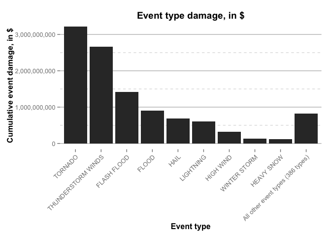

```r
econDamage$EVTYPE<-factor(econDamage$EVTYPE,levels=econDamage$EVTYPE)
ggplot(data=econDamage[1:10],aes(x=EVTYPE, y=NET_DAMAGE)) +
    geom_bar(stat = "identity") +
    scale_y_continuous(labels=comma) +
    labs(title="Event type damage, in $", x="Event type", y="Cumulative event damage, in $") +
    theme(title=element_text(face='bold')) +
    theme(axis.text.x=element_text(angle=45,hjust=1)) +
    theme(panel.background=element_rect(fill='white')) +
    theme(panel.grid.major=element_line(colour='gray')) +
    theme(panel.grid.major.x=element_blank()) +
    theme(panel.grid.minor.y=element_line(colour='gray',linetype='dashed'))
```